# ggLinearModel

`ggLinearModel` is a package designed to create easy linear model visualizations in one simple step. Using the `ggLinearModel` function the user has access many various types of linear models, including models with:

- the same slope
- the same intercept
- polynomial predictors
- varying number of interaction effects
- both confidence and prediction intervals, with the ability to change the confidence level
- interactive features to show the equation for LSRL or information about a specific data point
- ggplot or plotly style graphs

# Old vs. New

Although creating plots in R is super easy thanks to the creation of `ggplot`, adding multiple different items to a plot can be complex, and require lots of code. In this section, you will view the differences in code required to create different types of linear models and then visualize them.

### The full model

This model is the easiest to code in `ggplot`, with the most important part is the `geom_smooth(method = lm, ...)`. This ensures that the graph adds the least-squares regression lines for each category. Using `ggLinearModel()` we just input our dataset, or tibble, x variable, y variable, and categorical variable to create the same graph in much less code.

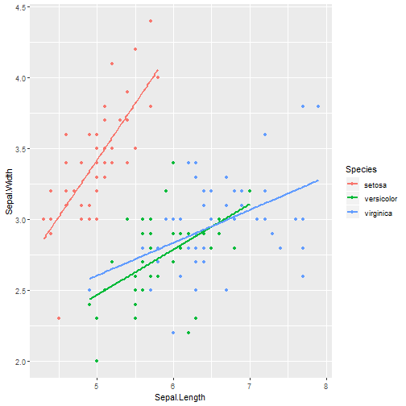

```r
ggplot(data = iris, aes(x = Sepal.Length, y = Sepal.Width, col = Species)) +
    geom_point() +
    geom_smooth(method = lm, se = FALSE)
```

```r
ggLinearModel(iris, Sepal.Length, Sepal.Width, Species)
```

[output not shown]

### Same slope model

Now let's assume that you want to create a visualization that shows the regression estimates as lines with the same slope, or when there no interaction effect involved. In `ggplot` we have no easy way to do this. We must first create our model, and instead of using the `geom_smooth()`. Then we add a new `geom_abline()` for each level in the dataset, with each `geom_abline()` having different inputs for the intercept parameter. This is going to get messy quickly with lots of levels in your categorical variable. Using `ggLinearModel(..., same_slope = TRUE)` the user will get the same process done in much less code and prevents you from making any mistakes when creating the different `geom_abline()`.

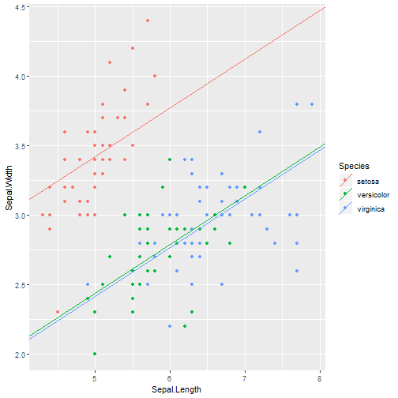

```r
model <- lm(Sepal.Width ~ Sepal.Length + Species, data = iris)
m <- model$coefficients[2]
b <- model$coefficients[1]
ggplot() +
    geom_point(data = iris, aes(x = Sepal.Length, y = Sepal.Width, col = Species)) +
    geom_abline(aes(slope = m,
                intercept = b,
                color = 'setosa')) +
    geom_abline(aes(slope = m,
                intercept = b + model$coefficients[3],
                color = 'versicolor')) +
    geom_abline(aes(slope = m,
                intercept = b + model$coefficients[4],
                color = 'virginica'))
```

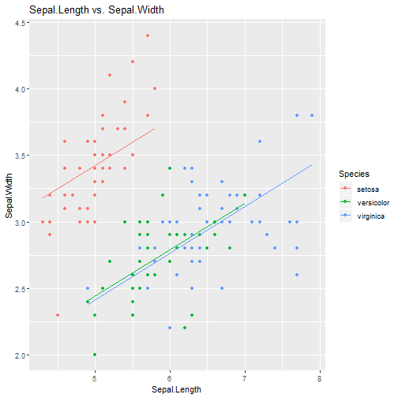

```r
ggLinearModel(iris, Sepal.Length, Sepal.Width, Species, same_slope = TRUE)
```

### Same intercept model

If a user wanted to create a model with the same intercept for each level of the categorical variable they would have to follow the same method as above, but instead, only include an interaction effect and not a categorical effect. Using `ggLinearModel` we can solve this problem but just adding the `ggLinearModel(..., same_intercept = TRUE)` parameter.

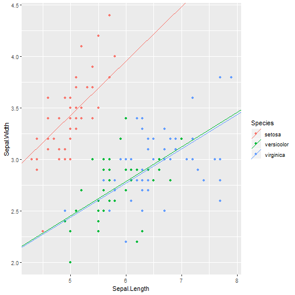

```r
model <- lm(Sepal.Width ~ Sepal.Length + Sepal.Length:Species, data = iris)
b <- model$coefficients[1]
m <- model$coefficients[2]
ggplot(data = iris, aes(x = Sepal.Length, y = Sepal.Width, col = Species)) +
    geom_point() +
    geom_abline(aes(intercept = b,
                    slope = m,
                    color = 'setosa')) +
    geom_abline(aes(slope = m + model$coefficients[3],
                    intercept = b,
                    color = 'versicolor')) +
    geom_abline(aes(slope = m + model$coefficients[4],
                    intercept = b,
                    col = 'virginica'))
```

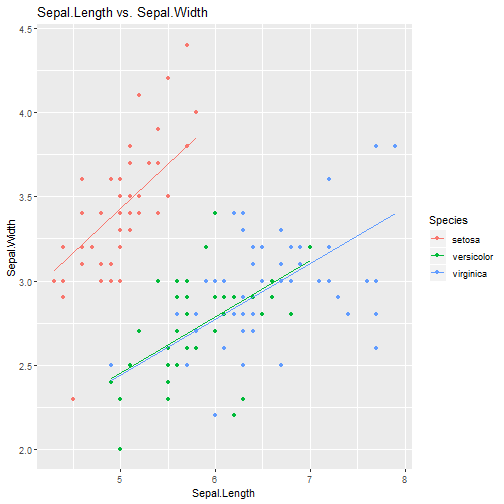

```r
ggLinearModel(iris, Sepal.Length, Sepal.Width, Species, same_intercept = TRUE)
```

### Polynomial model

Using `ggLinearModel` you can make models with any number of polynomial predictors. Just add the `poly` parameter to the function and assign it to the number of polynomial predictors you want in the model. This is a much easier solution than having to add a new `stat_function` to include each new curved line to the plot object.

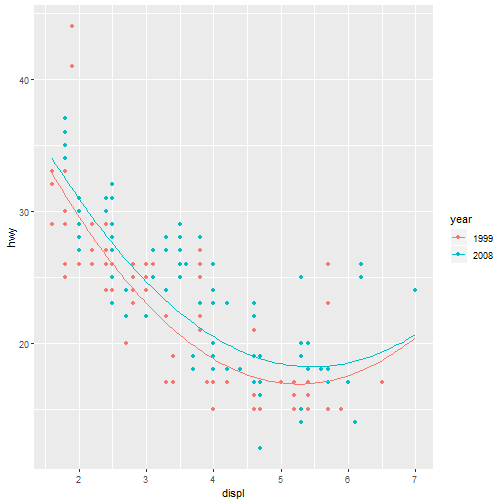

```r
mpg$year <- as.factor(as.character(mpg$year))
model <- lm(hwy ~ displ + I(displ^2) + displ:year + I(displ^2):year, data = mpg)
ggplot(data = mpg, aes(x = displ, y = hwy, col = year)) +
    geom_point() +
    stat_function(fun=function(x)
        model$coefficients[1] + model$coefficients[2]*x +
            model$coefficients[3]*x^2,
        aes(col = '1999')) +
    stat_function(fun=function(x)
        model$coefficients[1] + model$coefficients[2]*x +
            I(x^2)*model$coefficients[5]+model$coefficients[3]*x^2 + model$coefficients[4]*x,
        aes(col = '2008'))
```

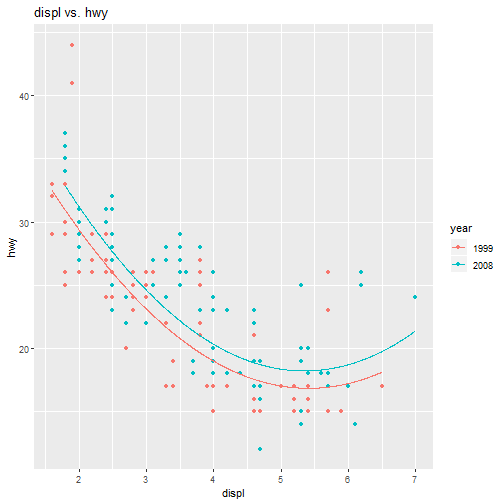

```r
ggLinearModel(mpg, displ, hwy, year, poly = 2)
```

### Polynomial model with fewer interactions

If it doesn't make sense to include a model with as many interaction effects as polynomial predictors you can modify this in the `ggLinearModel` function. As a default when using the `poly` parameter in the `ggLinearModel` function the function automatically assigns the number of interaction effects to be equal to the number of polynomial predictors. You can change this by setting the `interactions` parameter to a different number than what you set `poly` at. Of course, the `interactions` parameter will not work unless you set the `poly` parameter, and the `interactions` parameter must be equal or less to the `poly` parameter.

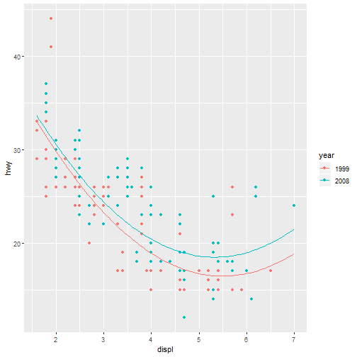

```r
model <- lm(hwy ~ displ + I(displ^2) + displ:year, data = mpg)
ggplot(data = mpg, aes(x = displ, y = hwy, col = year)) +
    geom_point() +
    stat_function(fun=function(x)
        model$coefficients[1] + model$coefficients[2]*x +
            model$coefficients[3]*x^2,
        aes(col = '1999')) +
    stat_function(fun=function(x)
        model$coefficients[1] + model$coefficients[2]*x +
            I(x^2)*model$coefficients[3] + model$coefficients[4]*x,
        aes(col = '2008'))
```

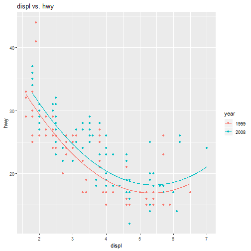

```r
ggLinearModel(mpg, displ, hwy, year, poly = 2, interactions = 1)
```

# Added Features

`ggLinearModel` provides the user with multiple extra features to create a visual that tells more than just a plain plot.

### Confidence Interval and Prediction Interval

If the user wanted to add interval ribbons to their plot it is as simple as changing a parameter. Setting `ci` or `pi` to TRUE will add a confidence interval, and setting `level` to a number between 0 and 1 will change the confidence level of the interval. As the default, the `level` is preset to .95. The user can add both the `ci` and `pi` to the same graph if the desires.

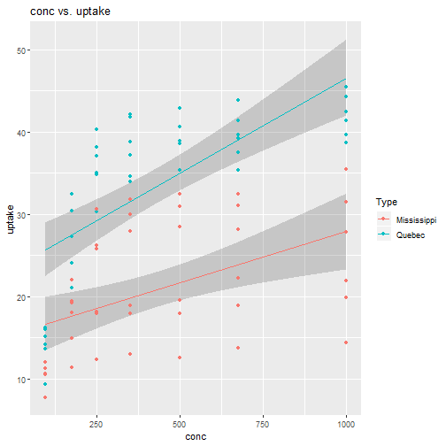

```r
ggLinearModel(CO2, conc, uptake, Type, ci = TRUE)
```

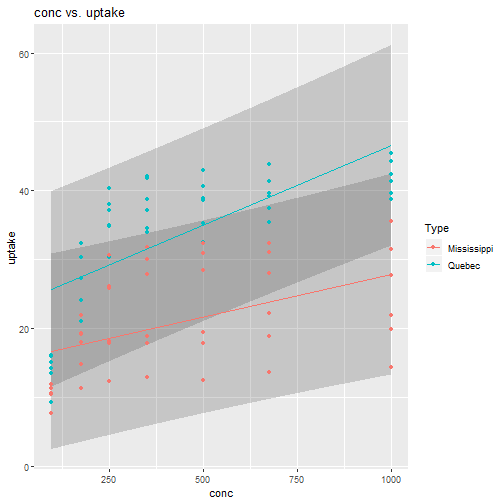

```r
ggLinearModel(CO2, conc, uptake, Type, pi = TRUE)
```

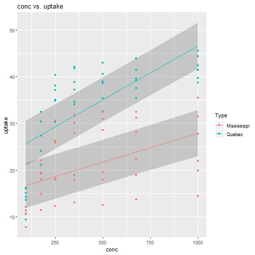

```r
ggLinearModel(CO2, conc, uptake, Type, pi = TRUE, level = .5)
```

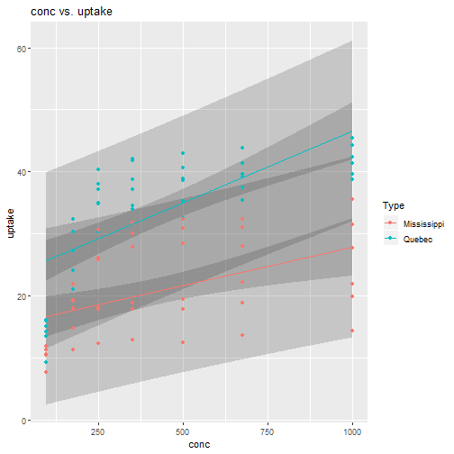

```r
ggLinearModel(CO2, conc, uptake, Type, ci = TRUE, pi = TRUE)
```

### Label name changing

Although `ggLinearModel()` will return a `ggplot` object you can still add a title, x-axis label, y-axis label, and legend title within `ggLinearModel()`.

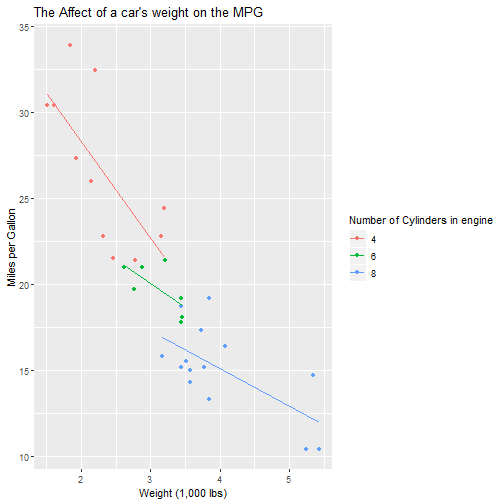

```r
ggLinearModel(mtcars, wt, mpg, cyl,
               title = "The Affect of a car's weight on the MPG", xlabel = 'Weight (1,000 lbs)',
               ylabel = 'Miles per Gallon', legendTitle = 'Number of Cylinders in engine')
```

### Models and their coefficients

`ggLinearModel(..., coefficients = TRUE)` will print the coefficients used to create the models and LSRL. However, if you want to get the whole model back use `ggLinearModel(..., model = TRUE)`. The user can later use this model to do predictions, create other plots using the model, and anything else the user may need a model for.

```r
ggLinearModel(iris, Sepal.Length, Sepal.Width, Species, coefficients = T)
```

```
#>                    (Intercept)                   Sepal.Length
#>                     -0.5694327                      0.7985283
#>              Speciesversicolor               Speciesvirginica
#>                      1.4415786                      2.0157381
#> Sepal.Length:Speciesversicolor  Sepal.Length:Speciesvirginica
#>                     -0.4788090                     -0.5666378
```

```r
ggLinearModel(iris, Sepal.Length, Sepal.Width, Species, model = T)
```

```
#> $model
#>
#> Call:
#> lm(formula = yvar ~ xvar * catvar, data = data)
#>
#> Coefficients:
#>                    (Intercept)                    Sepal.Length
#>                        -0.5694                          0.7985
#>              Speciesversicolor                Speciesvirginica
#>                         1.4416                          2.0157
#> Sepal.Length:Speciesversicolor   Sepal.Length:Speciesvirginica
#>                        -0.4788                         -0.5666
#>
#>
#> $plot
```

### No categorical variable?

No problem. `ggLinearModel()` works without giving a categorical variable and any parameters you want.

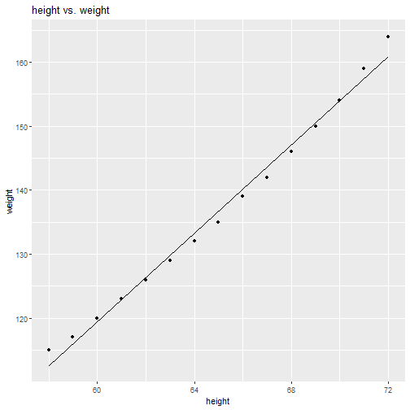

```r
ggLinearModel(women, height, weight)
```

### Adding on later

`ggLinearModel` always will return a plot. So if the user builds a plot using `ggLinearModel` and then later decides to add on it they can! It can be treated like any other `ggplot` item. This feature doesn't work if `plotly = TRUE`.

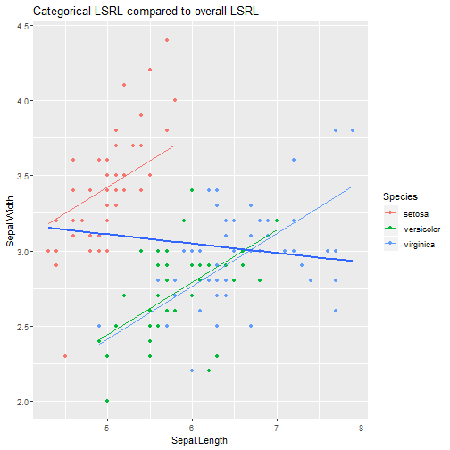

```r
plot <- ggLinearModel(iris, Sepal.Length, Sepal.Width, Species, same_slope = TRUE)
plot + geom_smooth(data = iris, aes(x = Sepal.Length, y = Sepal.Width), method = 'lm', se = FALSE) +
   ggtitle('Categorical LSRL compared to overall LSRL')
```

### Interactive and plotly features

You can create plots that will give the user more information about a data point when the user hovers over. Hovering over a line in the interactive plots will give the equation for the line. You can access these features using this example code `ggLinearModel(iris, Sepal.Length, Sepal.Width, Species, interactive = TRUE)`. If you prefer plotly style plots to the ggplots from above you can add the plotly parameter and set it to TRUE as such, `ggLinearModel(..., plotly = TRUE)` This will modify the ggplot object and turn it into a plotly object.